# 1st-level Analysis Workflow Structure

In this notebook we will create a workflow that performs 1st-level analysis and normalize the resulting beta weights to the MNI template. In concrete steps:

1. Specify 1st-level model parameters
2. Specify 1st-level contrasts
3. Estimate 1st-level contrasts
4. Normalize 1st-level contrasts

# Imports

```python
# Get the Node and Workflow object
from nipype import Node, Workflow
from nipype.interfaces import spm

# Specify which SPM to use
from nipype.interfaces.matlab import MatlabCommand
MatlabCommand.set_default_paths('/Users/hanningsu/Documents/MATLAB/spm12')
# This step basically specifies the spm we are going to use. Set the path to where spm is installed
```

```python
spm.SPMCommand.set_mlab_paths(paths='/Users/hanningsu/Documents/MATLAB/spm12/', matlab_cmd='/Applications/MATLAB_R2021a.app/bin/matlab -nodesktop -nosplash')
```

```python
print(spm.SPMCommand().version) # Check the version of spm we are using
```

```
12.7771
```

# Create Nodes and Workflow connections

```python
# Create the workflow here
analysis1st = Workflow(name="work_1st", base_dir='/Users/hanningsu/Desktop/Nipype_Tutorial/Analysis/output/')
```

## Specify 1st-level model parameters (stimuli onsets, duration, etc.)

To specify the 1st-level model we need the subject-specific onset times and duration of the stimuli. Luckily, as we are working with BIDS dataset, this information is nicelt stored in a tsv file.

```python
import pandas as pd
trialinfo = pd.read_table('/Users/hanningsu/Desktop/Nipype_Tutorial/data/ds000114/task-fingerfootlips_events.tsv')
trialinfo
```

|  | onset | duration | weight | trial_type |
| --- | --- | --- | --- | --- |
| 0 | 10 | 15.0 | 1 | Finger |
| 1 | 40 | 15.0 | 1 | Foot |
| 2 | 70 | 15.0 | 1 | Lips |
| 3 | 100 | 15.0 | 1 | Finger |
| 4 | 130 | 15.0 | 1 | Foot |
| 5 | 160 | 15.0 | 1 | Lips |
| 6 | 190 | 15.0 | 1 | Finger |
| 7 | 220 | 15.0 | 1 | Foot |
| 8 | 250 | 15.0 | 1 | Lips |
| 9 | 280 | 15.0 | 1 | Finger |
| 10 | 310 | 15.0 | 1 | Foot |
| 11 | 340 | 15.0 | 1 | Lips |
| 12 | 370 | 15.0 | 1 | Finger |
| 13 | 400 | 15.0 | 1 | Foot |
| 14 | 430 | 15.0 | 1 | Lips |

Using pandas, we can quickly aggregate stimuli information per condition.

```python
for group in trialinfo.groupby('trial_type'):
    print(group)
    print("")
```

```
('Finger',     onset  duration  weight trial_type
0      10      15.0       1     Finger
3     100      15.0       1     Finger
6     190      15.0       1     Finger
9     280      15.0       1     Finger
12    370      15.0       1     Finger)

('Foot',     onset  duration  weight trial_type
1      40      15.0       1       Foot
4     130      15.0       1       Foot
7     220      15.0       1       Foot
10    310      15.0       1       Foot
13    400      15.0       1       Foot)

('Lips',     onset  duration  weight trial_type
2      70      15.0       1       Lips
5     160      15.0       1       Lips
8     250      15.0       1       Lips
11    340      15.0       1       Lips
14    430      15.0       1       Lips)
```

```python
for group in trialinfo.groupby('trial_type'):
    print(group[0])
    print("")
```

```
Finger

Foot

Lips
```

```python
for group in trialinfo.groupby('trial_type'):
    print(list(group[1].onset))
    print("")
```

```
[10, 100, 190, 280, 370]

[40, 130, 220, 310, 400]

[70, 160, 250, 340, 430]
```

```python
for group in trialinfo.groupby('trial_type'):
    print(group[1].duration.tolist())
    print("")
```

```
[15.0, 15.0, 15.0, 15.0, 15.0]

[15.0, 15.0, 15.0, 15.0, 15.0]

[15.0, 15.0, 15.0, 15.0, 15.0]
```

To create a GLM model, Nipype needs an list of Bunch objects per session. In this tutorial, we only have one session, the template for the object is as follows:

```
[Bunch(conditions=['Finger', 'Foot', 'Lips'],
       durations=[[15.0, 15.0, 15.0, 15.0, 15.0],
                  [15.0, 15.0, 15.0, 15.0, 15.0],
                  [15.0, 15.0, 15.0, 15.0, 15.0]],
       onsets=[[10, 100, 190, 280, 370],
               [40, 130, 220, 310, 400],
               [70, 160, 250, 340, 430]]
       )]
```

We go on to create the Bunch object that we then can use for the GLM model.

```python
import pandas as pd
from nipype.interfaces.base import Bunch

trialinfo = pd.read_table('/Users/hanningsu/Desktop/Nipype_Tutorial/data/ds000114/task-fingerfootlips_events.tsv')
conditions = []
onsets = []
durations = []

for group in trialinfo.groupby('trial_type'):
    conditions.append(group[0])
    onsets.append(list(group[1].onset - 10)) # subtracting 10s due to removing of 4 dummy scans
    durations.append(group[1].duration.tolist())

subject_info = [Bunch(conditions=conditions,
                     onsets=onsets,
                     durations=durations,
                     )]

subject_info
```

```
[Bunch(conditions=['Finger', 'Foot', 'Lips'],
       durations=[[15.0, 15.0, 15.0, 15.0, 15.0],
        [15.0, 15.0, 15.0, 15.0, 15.0],
        [15.0, 15.0, 15.0, 15.0, 15.0]],
       onsets=[[0, 90, 180, 270, 360],
        [30, 120, 210, 300, 390],
        [60, 150, 240, 330, 420]])]
```

We then create the node that will create the SPM model. For this we will be using SpecifySPModel. TR of the acquisition is 2.5s and we want to use a high pass filter of 128.

```python
from nipype.algorithms.modelgen import SpecifySPMModel
```

```python
# Initialize the SpecifySPModel node here
modelspec = Node(SpecifySPMModel(concatenate_runs=False,
                                input_units='secs',
                                output_units='secs',
                                time_repetition=2.5,
                                high_pass_filter_cutoff=128,
                                subject_info=subject_info),
                name="modelspec")
```

This node will also need some additional inputs, such as the preprocessed functional images, the motion parameters and etc. We will specify those once we take case of the workflow data input stream.

## Specify 1st level contrast

To do any GLM analysis, we need to also define the contrasts that we want to investigate. If we recap, we had three different conditions in the fingerfootlips task in this dataset:

1. finger
2. foot
3. lips

Therefore, we could create the following contrasts (seven T-contrasts and two F-contrasts):

```python
# Condition names
condition_names = ['Finger', 'Foot', 'Lips']

# Contrasts
cont01 = ['average',        'T', condition_names, [1/3., 1/3., 1/3.]]
cont02 = ['Finger',         'T', condition_names, [1, 0, 0]]
cont03 = ['Foot',           'T', condition_names, [0, 1, 0]]
cont04 = ['Lips',           'T', condition_names, [0, 0, 1]]
cont05 = ['Finger < others','T', condition_names, [-1, 0.5, 0.5]]
cont06 = ['Foot < others',  'T', condition_names, [0.5, -1, 0.5]]
cont07 = ['Lips > others',  'T', condition_names, [-0.5, -0.5, 1]]
```

```python
[cont02, cont03, cont04]
```

```
[['Finger', 'T', ['Finger', 'Foot', 'Lips'], [1, 0, 0]],
 ['Foot', 'T', ['Finger', 'Foot', 'Lips'], [0, 1, 0]],
 ['Lips', 'T', ['Finger', 'Foot', 'Lips'], [0, 0, 1]]]
```

```python
cont08 = ['activation',     'F', [cont02, cont03, cont04]]
cont09 = ['differences',    'F', [cont05, cont06, cont07]]
```

```python
contrast_list = [cont01, cont02, cont03, cont04, cont05, cont06, cont07, cont08, cont09]
```

## Estimate 1st-level contrasts

Before we can estimate the 1st-levle contrasts, we first need to create the 1st-level design. Here you can also specify what kind of basis function you want (HRF, FIR, Forier, and etc), if you want to use time and dispersion derivatives and how you want to model the serial correlation.

Here, we use an HRF basis function, model time derivatives and model the serial correlation with AR(1).

```python
from nipype.interfaces.spm import Level1Design
```

```python
# Initiate the Level1Design node here
level1design = Node(Level1Design(bases={'hrf': {'derivs': [1,0]}},
                                timing_units='secs',
                                interscan_interval=2.5,
                                model_serial_correlations='AR(1)'),
                   name="level1design")
```

Now that we have the Model Specification and 1st-Level Design node, we can connect them to each other.

```python
# Connect the two nodes here
```

```python
analysis1st.connect([(modelspec, level1design, [('session_info',
                                               'session_info')])])
```

`connect([(source, dest, [("source_output1", "dest_input1")])] # Code format used above`

Now we need to estimate the model. It is recommended that we use a `Classical`: 1 method to estimate the model.

```python
from nipype.interfaces.spm import EstimateModel
```

```python
# Initiate the EstimateModel node here
level1estimate = Node(EstimateModel(estimation_method={'Classical': 1}),
                     name='level1estimate')
```

Now we can connect the 1st-Level Design node with the model estimation node.

```python
# Connect the two nodes here
analysis1st.connect([(level1design, level1estimate, [('spm_mat_file',
                                                     'spm_mat_file')])])
```

Now that we estimate the model, we can estimate the contrasts. Don't forget to feed the list of contrasts we specify above to this node.

```python
from nipype.interfaces.spm import EstimateContrast
```

```python
# Initiate the EstimateContrast node here
level1conest = Node(EstimateContrast(contrasts=contrast_list),
                   name='level1conest')
```

Now we can connect the model estimation node with the contrast estimation node.

```python
# Connecr the two nodes here
analysis1st.connect([(level1estimate, level1conest, [('spm_mat_file',
                                                     'spm_mat_file'),
                                                    ('beta_images',
                                                    'beta_images'),
                                                    ('residual_image',
                                                    'residual_image')])])
```

```
connect([(source, dest, [("source_output1", "dest_input1"),
                         ("source_output2", "dest_input2")
                         ])
         ])
```

## Normalize 1st-level contrasts

Now that the contrasts were estimated in subject space, we can put them into a common reference space by normalizing them to a specific template. In this case, we will be using SPM12's Normalization routine and normalize to the SPM12 tissue probability map `TPM.nii`.

At this step, you can also specify the voxel resolution of the output volumnes. If you don't specify it to a voxel resolution of 2 $\times$ 2 $\times$ 2 mm. As a training exercise, set the voxel-resolution to 4 $\times$ 4 $\times$ 4mm.

```python
from nipype.interfaces.spm import Normalize12

# Location of the template
template = '/Users/hanningsu/Documents/MATLAB/spm12/tpm/TPM.nii'
```

```python
# Initialize the Nomalize12 node here
normalize = Node(Normalize12(jobtype='estwrite',
                            tpm=template,
                            write_voxel_sizes=[4, 4, 4]
                            ),
                name="normalize")
```

Now we can connect the estimated contrasts to normalization node.

```python
# Connect the nodes here
analysis1st.connect([(level1conest, normalize, [('con_images',
                                                'apply_to_files')])
                    ])
```

# Datainput with SelectFiles and iterables

As in the preprocessing tutorial, we will again be using `SelectFiles` and `iterables`. So, what do we need?

From the preprocessing pipeline, we need the functional images, the motion parameters and the list of ourliers. Also, for the normalization, we need the subject-specific anatomy.

```python
# Import the SelectFiles
from nipype import SelectFiles

# String template with {}-based strings
templates = {'anat': '/Users/hanningsu/Desktop/Nipype_Tutorial/data/ds000114/sub-{subj_id}/ses-test/anat/sub-{subj_id}_ses-test_T1w.nii.gz',
             'func': '/Users/hanningsu/Desktop/Nipype_Tutorial/hands_on_preprocessing/output/datasink_handson/preproc/sub-{subj_id}_detrend.nii.gz',
             'mc_param': '/Users/hanningsu/Desktop/Nipype_Tutorial/hands_on_preprocessing/output/datasink_handson/preproc/sub-{subj_id}.par',
             'outliers': '/Users/hanningsu/Desktop/Nipype_Tutorial/hands_on_preprocessing/output/datasink_handson/preproc/art.sub-{subj_id}_outliers.txt'
    }

# Create SelectFiles node
sf = Node(SelectFiles(templates, sort_filelist=True),
         name='selectfiles')
```

Now we can specify over which subjects the workflow should iterate.

```python
# list of subject identifiers
subject_list = ['02', '03', '04', '07', '08', '09']
sf.iterables = [('subj_id', subject_list)]
```

```python
sf.iterables
```

```
[('subj_id', ['02', '03', '04', '07', '08', '09'])]
```

## Gunzip Node

We need to use a Gunzip node to unzip the detrend file and another one to unzip the anatomy image, before we can feed it to the model specification node.

```python
from nipype.algorithms.misc import Gunzip
```

```python
# Initiate the two Gunzip node here
gunzip_anat = Node(Gunzip(), name="gunzip_anat")
gunzip_func = Node(Gunzip(), name="gunzip_func")
```

And as a final step, we just need to connect this `SelectFiles` node to the rest of the workflow.

```python
# Connect SelectFiles node to the other nodes here
analysis1st.connect([(sf, gunzip_anat, [('anat', 'in_file')]),
                   (sf, gunzip_func, [('func', 'in_file')]),
                     (gunzip_anat, normalize, [('out_file', 'image_to_align')]),
                     (gunzip_func, modelspec, [('out_file', 'functional_runs')]),
                     (sf, modelspec, [('mc_param', 'realignment_parameters'),
                                     ('outliers', 'outlier_files')
                                     ])
                    ])
```

# Data output with Datasink

Now, before we run the workflow, let's again specify a `Datasink` folder to only keep those files that we want to keep.

```python
from nipype.interfaces.io import DataSink
```

```python
# Initialize DataSink node here
output_folder = 'datasink_handson'
datasink = Node(DataSink(base_directory='/Users/hanningsu/Desktop/Nipype_Tutorial/Analysis/output',
                        container=output_folder),
               name='datasink')
```

```python
# Use the following substitutions for the DataSink output
substitutions = [('_subj_id_', 'sub-')]
datasink.inputs.substitutions = substitutions
```

Now the next step is to specify all the output that we want to keep in our output folder output.

1. SPM.mat file and the spmT and spmF files from the contrast estimation node
2. normalized betas and anatomy

```python
# Connect nodes to datasink here
analysis1st.connect([(level1conest, datasink, [('spm_mat_file', '1stLevel.@spm_mat'),
                                              ('spmT_images', '1stLevel.@T'),
                                              ('spmF_images', '1stLeVEL.@F'),
                                              ]),
                     (normalize, datasink, [('normalized_files', 'normalized.@files'),
                                           ('normalized_image', 'normalized.@image'),
                                           ]),
])
```

# Visualize the workflow

Now that the workflow is finished, let's visualize it again.

```
210816-00:11:32,603 nipype.workflow INFO:
	 Generated workflow graph: /Users/hanningsu/Desktop/Nipype_Tutorial/Analysis/output/work_1st/graph.png (graph2use=colored, simple_form=True).
```

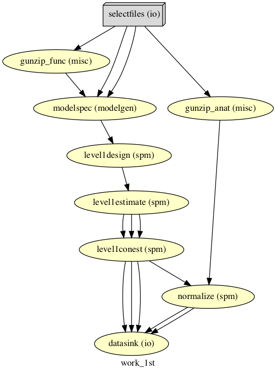

```python
# Create 1st-Level analysis output graph
analysis1st.write_graph(graph2use='colored', format='png', simple_form=True)

# Visualize the graph
from IPython.display import Image
Image(filename='/Users/hanningsu/Desktop/Nipype_Tutorial/Analysis/output/work_1st/graph.png')
```

# Run the Workflow

Now that everything is ready, we can run the 1st-level analysis workflow. Change n_procs to the number of jobs/cores you want to use.

```python
analysis1st.run('MultiProc', plugin_args={'n_procs':8})
```

[output not shown]

[output cut: 190 more lines]

```
	 [Job 44] Completed (work_1st.datasink).
210816-00:18:41,718 nipype.workflow INFO:
	 [MultiProc] Running 1 tasks, and 1 jobs ready. Free memory (GB): 7.00/7.20, Free processors: 7/8.
                     Currently running:
                       * work_1st.normalize
210816-00:18:43,703 nipype.workflow INFO:
	 [Job 16] Completed (work_1st.normalize).
210816-00:18:43,709 nipype.workflow INFO:
	 [Job 35] Completed (work_1st.datasink).
210816-00:18:43,714 nipype.workflow INFO:
	 [MultiProc] Running 0 tasks, and 1 jobs ready. Free memory (GB): 7.20/7.20, Free processors: 8/8.
210816-00:18:45,709 nipype.workflow INFO:
	 [Job 17] Completed (work_1st.datasink).
210816-00:18:45,715 nipype.workflow INFO:
	 [MultiProc] Running 0 tasks, and 0 jobs ready. Free memory (GB): 7.20/7.20, Free processors: 8/8.
```

```
<networkx.classes.digraph.DiGraph at 0x7fe7b83d1160>
```

# Visualize results

```python
%matplotlib inline
import numpy as np
from matplotlib import pyplot as plt
```

```python
from scipy.io import loadmat

# Using scipy's Loadmat function we can access SPM.mat
spmmat = loadmat('/Users/hanningsu/Desktop/Nipype_Tutorial/Analysis/output/datasink_handson/1stLevel/sub-07/SPM.mat',
                struct_as_record=False)
```

The design matrix and the names of the regressors are abit hidden in the spmmat variable, but they can be accessed as follows:

```python
designMatrix = spmmat['SPM'][0][0].xX[0][0].X
names = [i[0] for i in spmmat['SPM'][0][0].xX[0][0].name[0]]
```

```python
names
```

```
['Sn(1) Finger*bf(1)',
 'Sn(1) Finger*bf(2)',
 'Sn(1) Foot*bf(1)',
 'Sn(1) Foot*bf(2)',
 'Sn(1) Lips*bf(1)',
 'Sn(1) Lips*bf(2)',
 'Sn(1) Realign1',
 'Sn(1) Realign2',
 'Sn(1) Realign3',
 'Sn(1) Realign4',
 'Sn(1) Realign5',
 'Sn(1) Realign6',
 'Sn(1) Outlier1',
 'Sn(1) Outlier2',
 'Sn(1) Outlier3',
 'Sn(1) Outlier4',
 'Sn(1) Outlier5',
 'Sn(1) Outlier6',
 'Sn(1) Outlier7',
 'Sn(1) Outlier8',
 'Sn(1) Outlier9',
 'Sn(1) constant']
```

Before we can plot it we just need to normalize the design matrix in such a way, that each column has a maximum amplitude of 1. This is just for visualization purposes, otherwise the rotation parameters with their rather small values will not show up in the figure.

```python
normed_design = designMatrix / np.abs(designMatrix).max(axis=0)
```

Plot the design matrix

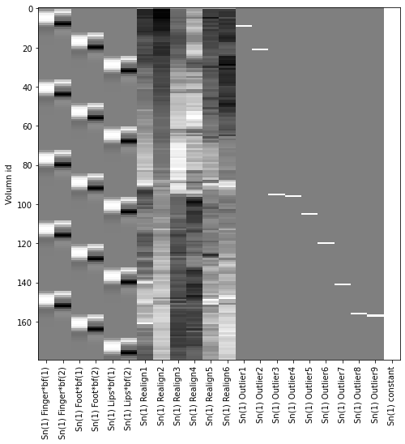

```python
fig, ax = plt.subplots(figsize=(8, 8))
plt.imshow(normed_design, aspect="auto", cmap='gray', interpolation='none')
ax.set_ylabel('Volumn id')
ax.set_xticks(np.arange(len(names)))
ax.set_xticklabels(names, rotation=90);
```

Now that we're happy with the design matrix, let's look how well the normalization worked.

```python
import nibabel as nb
from nilearn.plotting import plot_anat
from nilearn.plotting import plot_glass_brain
%matplotlib inline
```

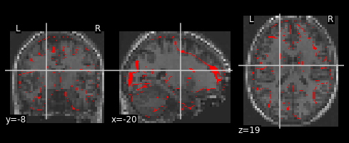

```python
# Load GM probability map of TPM.nii
img = nb.load('/Users/hanningsu/Documents/MATLAB/spm12/tpm/TPM.nii')
GM_template = nb.Nifti1Image(img.get_data()[..., 0], img.affine, img.header)

# plot normalized subject anatomy
display = plot_anat('/Users/hanningsu/Desktop/Nipype_Tutorial/Analysis/output/datasink_handson/normalized/sub-07/wsub-07_ses-test_T1w.nii',
                   dim=-0.1)

# Overlay in edges GM map
display.add_edges(GM_template)
```

Let's look at the contrasts of one subject that we've just computed in particular the F-contrast

```
<nilearn.plotting.displays.LYRZProjector at 0x7fe79f94e040>
```

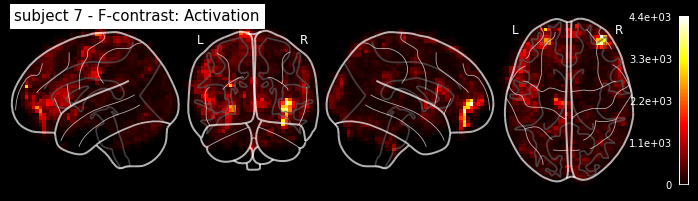

```python
plot_glass_brain('/Users/hanningsu/Desktop/Nipype_Tutorial/Analysis/output/datasink_handson/normalized/sub-07/wess_0008.nii',
                colorbar=True, display_mode='lyrz', black_bg=True, threshold=25,
                title="subject 7 - F-contrast: Activation")
```

```
<nilearn.plotting.displays.LYRZProjector at 0x7fe79e15d340>
```

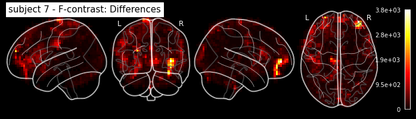

```python
plot_glass_brain('/Users/hanningsu/Desktop/Nipype_Tutorial/Analysis/output/datasink_handson/normalized/sub-07/wess_0009.nii',
                colorbar=True, display_mode='lyrz', black_bg=True, threshold=25,
                title="subject 7 - F-contrast: Differences")
```

# 2nd-level Analysis Workflow Strucutre

## Workflow for the 2nd-level analysis

```python
# Create the workflow here
analysis2nd = Workflow(name='work_2nd', base_dir='/Users/hanningsu/Desktop/Nipype_Tutorial/Analysis/output/')
```

## 2nd-Level Design

For the current example, we will be using a one-sample T-test design

```python
from nipype.interfaces.spm import OneSampleTTestDesign
```

```python
# Initialize the OneSampleTTestDesign node here
onesamplettestdes = Node(OneSampleTTestDesign(), name="onesampttestdes")
```

The next two steps are the same as for the 1st level design, i.e. estimation of the model followed by estimation of the contrasts

```python
from nipype.interfaces.spm import EstimateModel, EstimateContrast
```

```python
# Initiate the EstimateModel and the EstimateContrast node here
level2estimate = Node(EstimateModel(estimation_method={'Classical':1}),
                     name='level2estimate')

level2conestimate = Node(EstimateContrast(group_contrast=True),
                        name="level2conestimate")
```

To finish the EstimateContrast node, we also need to specify which contrast should be computed. For a 2nd-level one-sample t-test design, this is rather straightforward.

```python
cont01 = ['Group', 'T', ['mean'], [1]]
level2conestimate.inputs.contrasts = [cont01]
```

Now, let's connect those three desgin nodes to each other.

```python
# Connect OneSampleTTestDesign, EstimateModel and EstimateContrast here
analysis2nd.connect([(onesamplettestdes, level2estimate, [('spm_mat_file',
                                                          'spm_mat_file')]),
                     (level2estimate, level2conestimate, [('spm_mat_file',
                                                         'spm_mat_file'),
                                                         ('beta_images',
                                                         'beta_images'),
                                                         ('residual_image',
                                                         'residual_image')])
                    ])
```

## Thresholding of output contrast

```python
from nipype.interfaces.spm import Threshold
```

```python
level2thresh = Node(Threshold(contrast_index=1,
                             use_topo_fdr=True,
                             use_fwe_correction=False,
                             extent_threshold=0,
                             height_threshold=0.01,
                             height_threshold_type='p-value',
                             extent_fdr_p_threshold=0.05),
                   name='level2thresh')
```

```python
# Connect the Threshold node to the EstimateContrast node here
analysis2nd.connect([(level2conestimate, level2thresh, [('spm_mat_file',
                                                        'spm_mat_file'),
                                                       ('spmT_images',
                                                       'stat_image'),
                                                       ])
                    ])
```

## Gray Matter Mask

In step, we use a gray matter mask to restrict the analysis to only gray matter voxels.

in the 1st-level analysis, we normalized to SPM12's `TPM.nii` tissue probability atlas. Therefore, we could just take the gray matter probability map of this TPM.nii image (the first volume) and threshold it at a certain probability value to get a binary mask. Herem we use direct bask code.

```python
%%bash
TEMPLATE='/Users/hanningsu/Documents/MATLAB/spm12/tpm/TPM.nii'

# Extract the first volume with 'fslroi'
fslroi $TEMPLATE GM_PM.nii.gz 0 1

# Threshold the probability mask at 10%
fslmaths GM_PM.nii -thr 0.10 -bin /Users/hanningsu/Desktop/Nipype_Tutorial/Analysis/output/datasink_handson/GM_mask.nii.gz

# Unzip the mask and delete the GM_PM.nii file
gunzip /Users/hanningsu/Desktop/Nipype_Tutorial/Analysis/output/datasink_handson/GM_mask.nii.gz
rm GM_PM.nii.gz
```

Let's take a look at this mask

```
<OrthoSlicer3D: /Users/hanningsu/Desktop/Nipype_Tutorial/Analysis/output/datasink_handson/GM_mask.nii (121, 145, 121)>
```

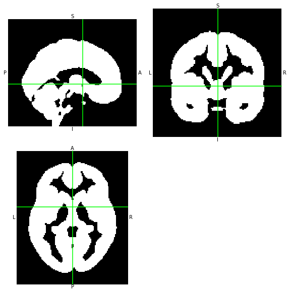

```python
import nibabel as nb
mask = nb.load('/Users/hanningsu/Desktop/Nipype_Tutorial/Analysis/output/datasink_handson/GM_mask.nii')
mask.orthoview()
```

Now we just need to specify this binary mask as an `explicit_mask_file` for the one-sample T-test node.

```python
onesamplettestdes.inputs.explicit_mask_file = '/Users/hanningsu/Desktop/Nipype_Tutorial/Analysis/output/datasink_handson/GM_mask.nii'
```

## Datainput with `SelectFiles` and `iterables`

We need the 1st-level contrasts of all subjects, separated by contrast number.

```python
# Inport the SelectFiles
from nipype import SelectFiles

# String template with {}-based strings
templates = {'cons': '/Users/hanningsu/Desktop/Nipype_Tutorial/Analysis/output/datasink_handson/normalized/sub-*/w*_{cont_id}.nii'}

# Create SelectFiles node
sf = Node(SelectFiles(templates, sort_filelist=True),
         name="selectfiles")
```

We are using *to to tell SelectFiles that it can grab all available subjects and any contrast, with a specific contrast id, independnet if it is an t-contrast (con) OR AN f-contrast(ess) contrast.

So let's specify over which contrast the workflow should iterate.

```python
# list of contrast identifiers
contrast_id_list = ['0001', '0002', '0003', '0004', '0005', '0006', '0007', '0008', '0009']
sf.iterables = [('cont_id', contrast_id_list)]
```

Now we need to connect the SelectFiles to the OneSampleTTestDesign node.

```python
analysis2nd.connect([(sf, onesamplettestdes, [('cons', 'in_files')])])
```

## Data output with `DataSink`

Now, before we run the workflow, let's again specify a `Datasink` folder to only keep those files that we want to keep.

```python
from nipype.interfaces.io import DataSink
```

```python
# Initiate Datasink node here
output_folder = 'datasink_handson'
datasink = Node(DataSink(base_directory='/Users/hanningsu/Desktop/Nipype_Tutorial/Analysis/output/',
                        container=output_folder),
               name="datasink")
```

```python
# Use the following substitutions for the DataSink output
substitutions = [('_cont_id', 'con_')]
datasink.inputs.substitutions = substitutions
```

```python
# Connect nodes to datasink here
analysis2nd.connect([(level2conestimate, datasink, [('spm_mat_file',
                                                    '2ndLevel.@spm_mat'),
                                                   ('spmT_images',
                                                   '2ndLevel.@T'),
                                                   ('con_images',
                                                   '2ndLevel.@con')]),
                    (level2thresh, datasink, [('thresholded_map',
                                              '2ndLevel.@threshold')])
                    ])
```

## Visualize the workflow

```
210816-19:25:38,539 nipype.workflow INFO:
	 Generated workflow graph: /Users/hanningsu/Desktop/Nipype_Tutorial/Analysis/output/work_2nd/graph.png (graph2use=colored, simple_form=True).
```

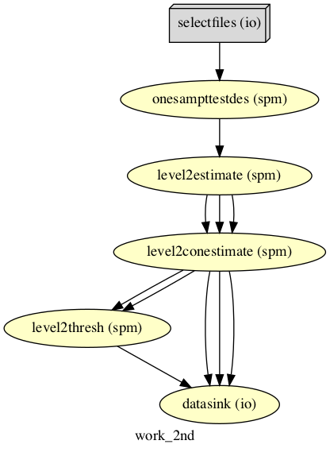

```python
# Create 2nd-level analysis output graph
analysis2nd.write_graph(graph2use='colored', format='png', simple_form=True)

# Visualize the graph
from IPython.display import Image
Image(filename='/Users/hanningsu/Desktop/Nipype_Tutorial/Analysis/output/work_2nd/graph.png')
```

## Run the Workflow

```python
analysis2nd.run('MultiProc', plugin_args={'n_procs':8})
```

[output not shown]

[output cut: 147 more lines]

```
                     Currently running:
                       * work_2nd.level2thresh
                       * work_2nd.level2thresh
210816-19:38:41,641 nipype.workflow INFO:
	 [Job 4] Completed (work_2nd.level2thresh).
210816-19:38:41,647 nipype.workflow INFO:
	 [Job 10] Completed (work_2nd.level2thresh).
210816-19:38:41,652 nipype.workflow INFO:
	 [MultiProc] Running 0 tasks, and 2 jobs ready. Free memory (GB): 7.20/7.20, Free processors: 8/8.
210816-19:38:43,647 nipype.workflow INFO:
	 [Job 5] Completed (work_2nd.datasink).
210816-19:38:43,652 nipype.workflow INFO:
	 [Job 11] Completed (work_2nd.datasink).
210816-19:38:43,658 nipype.workflow INFO:
	 [MultiProc] Running 0 tasks, and 0 jobs ready. Free memory (GB): 7.20/7.20, Free processors: 8/8.
```

```
<networkx.classes.digraph.DiGraph at 0x7fe7680ef670>
```

# Visualize results

```python
%matplotlib inline
from nilearn.plotting import plot_glass_brain
out_path = '/Users/hanningsu/Desktop/Nipype_Tutorial/Analysis/output/datasink_handson/2ndLevel/'
```

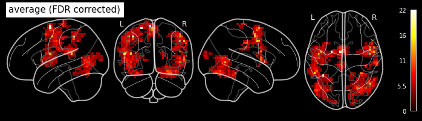

```python
plot_glass_brain(out_path + 'con__0001/spmT_0001_thr.nii', display_mode='lyrz',
                black_bg=True, colorbar=True, title="average (FDR corrected)");
```

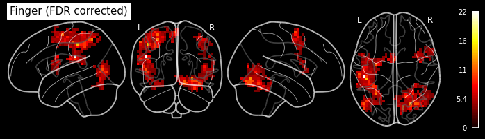

```python
plot_glass_brain(out_path + 'con__0002/spmT_0001_thr.nii', display_mode='lyrz',
                black_bg=True, colorbar=True, title="Finger (FDR corrected)");
```

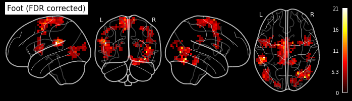

```python
plot_glass_brain(out_path + 'con__0003/spmT_0001_thr.nii', display_mode='lyrz',
                black_bg=True, colorbar=True, title="Foot (FDR corrected)");
```

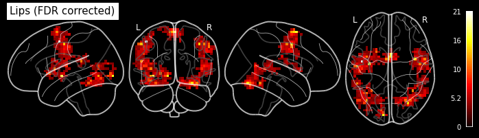

```python
plot_glass_brain(out_path + 'con__0004/spmT_0001_thr.nii', display_mode='lyrz',
                black_bg=True, colorbar=True, title="Lips (FDR corrected)");
```

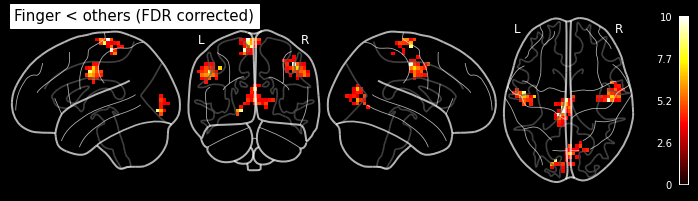

```python
plot_glass_brain(out_path + 'con__0005/spmT_0001_thr.nii', display_mode='lyrz',
                black_bg=True, colorbar=True, title="Finger < others (FDR corrected)");
```

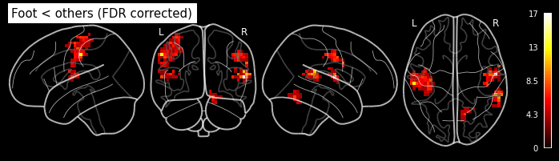

```python
plot_glass_brain(out_path + 'con__0006/spmT_0001_thr.nii', display_mode='lyrz',
                black_bg=True, colorbar=True, title="Foot < others (FDR corrected)");
```

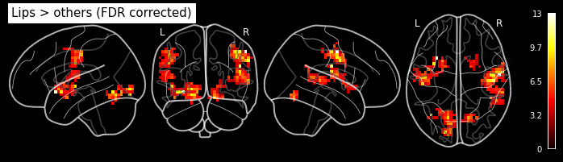

```python
plot_glass_brain(out_path + 'con__0007/spmT_0001_thr.nii', display_mode='lyrz',
                black_bg=True, colorbar=True, title="Lips > others (FDR corrected)");
```